# Stage 3a: the German labour market and disaggregated prices

A wage–price loop and a second cross-country channel — what the data allowed, what the identification assessment found, and which coefficient came out wrong

## 1. What was built, and why it looks like this

Stage 2b linked eleven economies through **one** channel: trade-weighted foreign demand over partners’ GDP. Stage 3a adds a second — price competitiveness — and gives Germany a labour block so that wages, unit labour costs and prices form a loop rather than a chain.

Germany’s block, as estimated (`covid_*` dummies elided):

```
de_consumption      ~ de_gdp + de_real_income + de_consumption.L(1)
de_investment       ~ de_gdp + de_long_rate + de_investment.L(1)
de_exports          ~ de_foreign_demand + de_export_prices + de_foreign_prices + de_exports.L(1)
de_imports          ~ de_domestic_demand + de_imports.L(1)
de_long_rate        ~ de_prices + ea_policy_rate + de_gdp + de_long_rate.L(1)
de_employment       ~ de_gdp + de_employment.L(1)
de_unemployment     ~ de_gdp + de_unemployment.L(1)
de_wages            ~ de_unemployment + de_prices + de_wages.L(1)
de_nonenergy_prices ~ de_ulc + de_import_prices + de_unemployment + de_nonenergy_prices.L(1)
de_energy_prices    ~ oil_price + eur_usd + de_energy_prices.L(1)
de_import_prices    ~ eur_usd + oil_price + de_foreign_prices + de_import_prices.L(1)
de_export_prices    ~ de_ulc + de_foreign_prices + de_export_prices.L(1)

de_gdp             == <expenditure shares>
de_domestic_demand == <expenditure shares>
de_foreign_demand  == <trade-weighted partners' gdp + row_gdp>
de_productivity    == de_gdp - de_employment
de_ulc             == de_wages - de_productivity
de_prices          == 0.891*de_nonenergy_prices + 0.109*de_energy_prices
de_real_income     == de_wages + de_employment - de_prices
de_foreign_prices  == <trade-weighted partners' export_prices>   [exogenous in phase A]
```

Three things in that listing differ from the block as originally specified. Each is a data finding, not a preference.

### 1.1 `de_wages` is a wage *rate*, because otherwise the identities are wrong

EA-MD/QD publishes `WS`, “Wages and salaries” in current prices — a whole-economy wage **bill**, not a wage rate. Used directly it breaks the block in two places: `real_income == wages + employment - prices` would double-count employment (the bill is already rate × employment), and a wage Phillips curve run on the bill would largely re-estimate Okun’s law.

`de_wages` is therefore `WS / TEMP`, labour income per worker. That makes the whole block internally exact: `ulc == wages - productivity` telescopes through `productivity == gdp - employment` to `WS - GDP`, nominal wage bill over real output — the textbook definition of unit labour costs. This matters because EA-MD/QD carries **no whole-economy ULC series at all**, only seven sectoral ones, so ULC has to be derived either way; deriving it this way makes it consistent with the rest of the block by construction.

The stated assumption: `WS` covers employees while `TEMP` counts total employment, so this imputes employee compensation to the self-employed. That is the standard construction for compensation per worker, and it is preferred to `WS / EMP` because mixing employment concepts between `wages` and `employment` would break the exactness above.

### 1.2 The price identity splits energy from non-energy, not core from energy

The specified identity was `prices == 0.85*core + 0.15*energy`. It cannot be made exact: HICP “core” excludes energy **and** food, so core plus energy covers only about 81% of the German basket and the missing food weight would have to be renormalised away — silently attributing food inflation to core, inside the very loop the block exists to model.

Eurostat’s `NRG` and `TOT_X_NRG` do partition the basket. Verified against `prc_hicp_inw` for every year from 1996 to 2025, they sum to `CP00` = 1000 exactly, with no residual. The identity uses those, and the weights come from the data rather than the example:

HICP weights for Germany, averaged over 2000-2024 (Eurostat prc_hicp_inw). Exact partition: TRUE.

| component | weight | specified |
| --- | --- | --- |
| non-energy (TOT_X_NRG) | 0.8913 | 0.85 |
| energy (NRG) | 0.1087 | 0.15 |

The energy weight is **0.109**, not the 0.15 assumed — a 4-point difference in the weight on the most volatile component of the basket.

Weights are re-based annually, so a fixed identity weight is an approximation. Over this window the German energy weight ranges from 88.4 to 125.5 per mille; the largest single-year departure from the average used here is **0.0203** in weight units. That is the size of the approximation, stated rather than buried.

Because “core” no longer appears in the identity, the block uses a new concept `nonenergy_prices` rather than redefining the existing `core_prices`. Nothing was silently repurposed; `de_core_prices` is still in the panel, still `HICPNEF`, and is now simply unused by any equation.

### 1.3 The price variables feed back into exports, but not imports

As originally specified, `de_export_prices` appeared on no other equation’s right-hand side inside a German-only system — it would have been estimated and then transmitted nothing, the same terminal-variable pathology `CLAUDE.md` already records for `long_rate`. Exports therefore take a relative-price pair (own and competitors’), which identifies well and comes back nearly equal and opposite.

Imports take **no** price term. The symmetric choice was estimated four ways and rejected every time; section 5.1 is the evidence. This is the one substantive specification change stage 3a makes relative to the block as designed, and it is the reason the competitiveness channel is one-sided.

## 2. Degrees of freedom: what fits and what does not

k = 1 + one lag column per stochastic equation + exogenous variables; T = 98.

| system | stochastic | identities | k | df | status |
| --- | --- | --- | --- | --- | --- |
| stage 2b | 68 | 35 | 76 | 22 | estimated |
| stage 3a phase A | 74 | 39 | 83 | 15 | estimated (this report) |
| stage 3a phase B | 84 | 40 | 92 | 6 | planned |
| full block, all 11 | 134 | 90 | 142 | -44 | impossible |

The last row is the important one. Rolling this block out to all eleven countries needs 142 predetermined columns against 98 observations — not slow, not badly conditioned, but **arithmetically impossible**: koma projects every equation on the full `k`-column `x_matrix` on every draw and draws `Omega` from `riwish(T - k, .)`. Even three countries would leave `df ≈ 4`. The block is a German pilot in the strict sense that the architecture cannot support it everywhere.

This report covers **phase A** (`k = 83`, `T = 98`, `df = 15`), where `de_foreign_prices` is an exogenous series constructed from partners’ export-price data. Phase B makes it endogenous by giving the other ten countries a one-equation export-price satellite, at `df = 6`.

## 3. Identification

`koma::model_identification()` checks the classical order and rank conditions per stochastic equation, symbolically, and **aborts** on failure. `stage2_preflight()` repeats it across ten seeds, because the function fills free coefficients with `rnorm` draws and a single pass proves little.

stage2_preflight(), phase A.

| check | ok | detail |
| --- | --- | --- |
| identity RHS variables all resolve | TRUE | - |
| no variable defined twice | TRUE | - |
| every variable has a panel series | TRUE | 121 variables present |
| no internal NAs in required series | TRUE | - |
| identities declared last | TRUE | 74 stochastic then 39 identities |
| system identified | TRUE | 10/10 seeds pass order + rank |
| k < T (x’x invertible, Wishart df > 0) | TRUE | k = 83, T = 98, df = 15 |

**No equation is under-identified.** The order condition requires each equation to exclude at least `n_endogenous - 1` = 112 variables; the stacked `[Gamma; B]` has 187 rows and no equation includes more than five regressors, so every equation excludes on the order of 200. Adding endogenous variables raises the bar for every equation but adds rows faster than it raises it. Rank is the binding condition and it passes on all ten seeds.

Two caveats on that result, neither of which the check itself would show:

- koma’s `gamma_vectorization()` locates parameters with an **unanchored** `grep`, so `"gamma1_6"` also matches `"gamma1_60"`. With 113 endogenous variables, index collisions are possible. Treat a pass as necessary, not sufficient.
- Identification is symbolic: it sees which variables are *excluded*, never how correlated the *included* ones are. That is a different question, and it is the one asked next.

### 3.1 Collinearity: the `ulc` / `unemployment` question, answered

The specific concern was that `de_nonenergy_prices` takes both `de_ulc` and `de_unemployment`, while `de_ulc == de_wages - de_productivity` and `de_wages` responds to unemployment — so ULC is partly a function of unemployment by construction. That would be weak identification (imprecise, trading-off coefficients), not rank failure.

Measured directly from the panel, in the rate space koma estimates in:

Variance inflation factors, worst first. Flagged above 10.

| equation | term | vif | max_abs_cor | worst_partner |
| --- | --- | --- | --- | --- |
| es_investment | es_gdp | 18.852 | 0.768 | covid_2020q2 |
| fr_imports | fr_domestic_demand | 17.083 | 0.723 | covid_2020q3 |
| es_consumption | es_gdp | 15.524 | 0.768 | covid_2020q2 |
| fr_investment | fr_gdp | 14.592 | 0.669 | covid_2020q3 |
| fr_consumption | fr_gdp | 14.570 | 0.669 | covid_2020q3 |
| be_investment | be_gdp | 11.280 | 0.706 | covid_2020q2 |
| be_consumption | be_gdp | 11.091 | 0.706 | covid_2020q2 |
| it_investment | it_gdp | 10.990 | 0.642 | covid_2020q2 |
| it_consumption | it_gdp | 9.402 | 0.642 | covid_2020q2 |
| pt_investment | pt_gdp | 9.298 | 0.701 | covid_2020q2 |
| pt_exports | pt_foreign_demand | 8.992 | 0.755 | covid_2020q2 |
| es_imports | es_domestic_demand | 8.531 | 0.737 | covid_2020q2 |

The weakest spot is elsewhere: `de_export_prices` and `de_foreign_prices` in the exports equation correlate at 0.854. Both are price indices in a common inflation environment, so separating an own-price from a competitor-price effect is the least well-identified thing the block asks for. Their estimated coefficients are nearly equal and opposite, which is what a relative price should look like, but the credible intervals are correspondingly wide.

Note also that had `de_wages` and `de_ulc` *both* entered the price equation — as the original sketch suggested — that would be algebraically identical to including `de_wages` and `de_productivity`. Legitimate and full rank, but it should then be written that way.

## 4. Sampler behaviour

### 4.1 Acceptance rates

The seven new behavioural equations, after tau tuning.

| equation | has_mh_step | acceptance_rate | flagged |
| --- | --- | --- | --- |
| de_employment | TRUE | 0.420 | FALSE |
| de_unemployment | TRUE | 0.434 | FALSE |
| de_wages | TRUE | 0.446 | FALSE |
| de_nonenergy_prices | TRUE | 0.315 | FALSE |
| de_energy_prices | FALSE | NA | FALSE |
| de_import_prices | FALSE | NA | FALSE |
| de_export_prices | TRUE | 0.398 | FALSE |

`de_energy_prices` and `de_import_prices` show `has_mh_step = FALSE` and an `NA` rate. That is correct, not a failure: in phase A every regressor in both equations (`oil_price`, `eur_usd`, and the exogenous `de_foreign_prices`) is exogenous, so neither has a contemporaneous endogenous regressor, koma gives them no Metropolis step, and `check_acceptance_rates()` never flags them. **This changes in phase B**, when `de_foreign_prices` becomes endogenous and `de_import_prices` acquires a Metropolis step for the first time.

An untuned stage-3a fit flagged 29 equations against a tuned stage-2b baseline of zero — but only three of those were new equations, and the rest were pre-existing equations pushed just over 60% by the system-wide change in the residual covariance. Acceptance rates are not a per-equation property in a simultaneous system: adding equations anywhere moves every equation’s rate. Re-tuning from the same doubling rule stage 2b used (`tune_tau_system()`) is what the table above reflects; attributing the untuned flags to the labour block would have been wrong.

### 4.2 The wage–price loop is not explosive

Stage 3a introduces a contemporaneous feedback loop that no earlier stage had: `wages → ulc → nonenergy_prices → prices → wages`. Its round-trip gain is `beta(nonenergy ← ulc) × w_nonenergy × beta(wages ← prices)`, and a draw with gain at or above 1 is one where a wage rise more than pays for itself through prices. koma constrains no draw to be stationary, so what matters is the share of the posterior above 1, not the average.

Posterior distribution of the wage-price loop gain.

| statistic | value |
| --- | --- |
| mean | 0.00550 |
| median | 0.00156 |
| 5th pct | -0.13327 |
| 95th pct | 0.13766 |
| share \|gain\| >= 1 | 0.00000 |

The gain is centred near zero and **no draw** reaches 1. The loop exists but is weak, and it does not add to the explosive-draw problem documented in `R/spillovers.R`.

### 4.3 Own-lag persistence

Most persistent own lags. Flagged at |coefficient| >= 1.

| equation | term | estimate | ci_high | flagged |
| --- | --- | --- | --- | --- |
| de_unemployment | de_unemployment.L(1) | 1.000 | 1.035 | FALSE |
| ea_policy_rate | ea_policy_rate.L(1) | 0.981 | 1.055 | FALSE |
| ie_long_rate | ie_long_rate.L(1) | 0.969 | 1.119 | FALSE |
| pt_long_rate | pt_long_rate.L(1) | 0.964 | 1.102 | FALSE |
| es_long_rate | es_long_rate.L(1) | 0.961 | 1.081 | FALSE |
| us_policy_rate | us_policy_rate.L(1) | 0.954 | 1.065 | FALSE |
| at_long_rate | at_long_rate.L(1) | 0.942 | 1.075 | FALSE |
| gr_long_rate | gr_long_rate.L(1) | 0.941 | 1.120 | FALSE |

Nothing is flagged, but `de_unemployment` sits **exactly at the boundary**: its own-lag coefficient is 0.9999 with a credible interval reaching 1.035. That is a unit root in all but name: the equation is a random walk with a GDP term, so an unemployment shock never dies out. For a rate modelled in levels (`series_type = "rate"`, `method = "none"`) this is common and not by itself wrong — the pre-existing `ea_policy_rate` and several `long_rate` equations sit at 0.96-0.98 for the same reason — but it does mean the Okun channel in this fit transmits GDP to a *permanently* shifted unemployment level, and anything reading unemployment at long horizons should treat that as a modelling artefact rather than a finding.

### 4.4 Precision: the block is estimable, but not sharply

Every coefficient in the seven new equations.

| equation | term | estimate | ci_low | ci_high | spans_zero |
| --- | --- | --- | --- | --- | --- |
| de_employment | de_employment.L(1) | 0.625 | 0.295 | 0.961 | FALSE |
| de_employment | de_gdp | 0.098 | 0.040 | 0.157 | FALSE |
| de_unemployment | de_unemployment.L(1) | 1.000 | 0.965 | 1.035 | FALSE |
| de_unemployment | de_gdp | -0.036 | -0.085 | 0.016 | TRUE |
| de_wages | de_wages.L(1) | -0.172 | -0.690 | 0.379 | TRUE |
| de_wages | de_unemployment | -0.136 | -0.327 | 0.038 | TRUE |
| de_wages | de_prices | 0.018 | -0.618 | 0.643 | TRUE |
| de_nonenergy_prices | de_nonenergy_prices.L(1) | 0.179 | -0.377 | 0.691 | TRUE |
| de_nonenergy_prices | de_unemployment | -0.030 | -0.150 | 0.103 | TRUE |
| de_nonenergy_prices | de_import_prices | 0.051 | -0.115 | 0.252 | TRUE |
| de_nonenergy_prices | de_ulc | 0.185 | -0.106 | 0.444 | TRUE |
| de_energy_prices | de_energy_prices.L(1) | 0.420 | 0.150 | 0.687 | FALSE |
| de_energy_prices | eur_usd | -0.220 | -0.425 | -0.014 | FALSE |
| de_energy_prices | oil_price | 0.127 | 0.080 | 0.177 | FALSE |
| de_import_prices | de_import_prices.L(1) | 0.087 | -0.165 | 0.343 | TRUE |
| de_import_prices | eur_usd | -0.064 | -0.146 | 0.024 | TRUE |
| de_import_prices | oil_price | 0.008 | -0.026 | 0.041 | TRUE |
| de_import_prices | de_foreign_prices | 1.149 | 0.645 | 1.666 | FALSE |
| de_export_prices | de_export_prices.L(1) | 0.309 | 0.044 | 0.576 | FALSE |
| de_export_prices | de_foreign_prices | 0.533 | 0.323 | 0.740 | FALSE |
| de_export_prices | de_ulc | 0.066 | -0.118 | 0.265 | TRUE |

12 of 21 coefficients in the new equations have credible intervals spanning zero. The signs are right, but at `df = 15` the magnitudes are not sharply identified — most visibly the wage-indexation term `de_wages ← de_prices` (0.018, interval [-0.62, 0.64]), which is the return leg of the wage-price loop and is why the loop gain in 4.2 is so close to zero. The loop is present in the structure and weak in the estimates; do not read the near-zero gain as evidence that wage-price feedback is *absent* in the German economy, only that this window and this specification do not pin it down.

## 5. Coefficient plausibility

Sign checks. Posterior means only; a check that could not be evaluated counts as a failure.

| check | equation | term | estimate | expected | ok |
| --- | --- | --- | --- | --- | --- |
| mpc_in_0_1 | de_consumption | de_gdp | 0.1327 | in (0, 1) | TRUE |
| import_elasticity_positive | de_imports | de_domestic_demand | 0.5240 | > 0 | TRUE |
| long_rate_loads_on_policy_rate | de_long_rate | ea_policy_rate | 0.0600 | > 0 | TRUE |
| okun_employment_positive | de_employment | de_gdp | 0.0976 | > 0 | TRUE |
| okun_unemployment_negative | de_unemployment | de_gdp | -0.0358 | < 0 | TRUE |
| wage_phillips_curve_negative | de_wages | de_unemployment | -0.1362 | < 0 | TRUE |
| wage_price_indexation_in_0_1 | de_wages | de_prices | 0.0185 | in (0, 1) | TRUE |
| ulc_passthrough_positive | de_nonenergy_prices | de_ulc | 0.1850 | > 0 | TRUE |
| import_price_passthrough_positive | de_nonenergy_prices | de_import_prices | 0.0510 | > 0 | TRUE |
| price_phillips_curve_negative | de_nonenergy_prices | de_unemployment | -0.0302 | < 0 | TRUE |
| energy_prices_load_on_oil | de_energy_prices | oil_price | 0.1268 | > 0 | TRUE |
| energy_prices_fall_on_euro_appreciation | de_energy_prices | eur_usd | -0.2204 | < 0 | TRUE |
| import_prices_fall_on_euro_appreciation | de_import_prices | eur_usd | -0.0642 | < 0 | TRUE |
| import_prices_load_on_oil | de_import_prices | oil_price | 0.0080 | > 0 | TRUE |
| import_prices_load_on_foreign_prices | de_import_prices | de_foreign_prices | 1.1493 | > 0 | TRUE |
| export_prices_load_on_ulc | de_export_prices | de_ulc | 0.0660 | > 0 | TRUE |
| export_prices_load_on_foreign_prices | de_export_prices | de_foreign_prices | 0.5334 | > 0 | TRUE |
| consumption_loads_on_real_income | de_consumption | de_real_income | 0.2314 | > 0 | TRUE |
| exports_fall_in_own_price | de_exports | de_export_prices | -0.9235 | < 0 | TRUE |
| exports_rise_in_competitor_price | de_exports | de_foreign_prices | 1.2587 | > 0 | TRUE |

**All 20 pass**, in the adopted specification. Every central economic claim the block makes holds:

- **The wage Phillips curve has the right sign.** `de_wages ← de_unemployment` = -0.1362. This was the designated red flag, and it is not raised.
- The price Phillips curve is also negative, ULC pass-through into non-energy prices is positive, and Okun’s law holds in both the employment and unemployment equations.
- Both euro-appreciation rules pass with the correct (negative) sign, which is worth noting because `eur_usd` is quoted USD per EUR — a rise is a euro appreciation, and the intuitive sign is backwards.
- Exports fall in their own price and rise in competitors’, nearly symmetrically, which is what makes the new competitiveness channel behave like a relative price rather than a price level.

### 5.1 The import-price term: tried four ways, then dropped

The imports equation above carries **no price term**. It did originally, and removing it is the one substantive specification change stage 3a makes relative to the block as designed. This section is the evidence for that decision, because “we tried it and it did not work” is only worth acting on if the trying is on the record.

**A first hypothesis, tested and rejected.** The obvious explanation was a specification asymmetry: exports received a relative-price *pair* (own and competitors’), while imports received only their own price, with no domestic counterpart to be relative *to*. That predicts the fix `de_imports ~ de_domestic_demand + de_import_prices + de_prices + ...`, which costs no degrees of freedom. It was estimated and it **does not work** — the coefficient moves further the wrong way, and the added domestic-price term takes the wrong sign too:

The imports equation across five specifications.

| specification | domestic_demand | import_price | import_price_ci |
| --- | --- | --- | --- |
| stage 2b (no price term) | 0.382 | NA | NA |
| own price, contemporaneous | 0.078 | 0.695 | [0.06, 1.35] |
| own price + domestic price | 0.027 | 0.799 | [0.01, 1.63] |
| own price, LAGGED one quarter | 0.386 | 0.401 | [-0.29, 1.10] |
| ADOPTED: no price term | 0.524 | NA | NA |

**The revised diagnosis is simultaneity, and the table above is the evidence.** Three things point the same way:

1. Adding a contemporaneous import price **collapses the demand elasticity**, from 0.38 in stage 2b to 0.08 with the price term and 0.03 in the variant. The price term is absorbing the scale variation that domestic demand should be carrying, which is what an omitted common driver looks like.
2. In the variant the two price coefficients come out as roughly `+0.7 × (import_prices − domestic_prices)` — a *relative* price with the wrong sign, not a mis-specified level. Adding the counterpart did not reveal a relative price; it reproduced the same contamination twice.
3. `de_import_prices` is itself driven by `oil_price` and `eur_usd` — global variables. The imports equation contains no control for world activity (`row_gdp` and `de_foreign_demand` appear in *exports*, not imports), so within a quarter the import deflator is the best available proxy for a global impulse that also raises German import volumes.

In other words the coefficient is not a demand elasticity at all: it is the within-quarter correlation between a commodity-driven deflator and commodity-driven volumes, with nothing in the equation to separate them.

**The decisive test: lag the import price.** That breaks the within-quarter channel while keeping the variable. The prediction was that the sign would turn negative. It **half** worked, and the half that failed is as informative as the half that succeeded:

- **The demand elasticity is fully restored.** It returns to 0.386, against 0.382 in stage 2b — the contamination is gone, and this is the clearest confirmation that the contemporaneous term was stealing the scale variation.
- **The price coefficient does not flip.** It halves, to 0.401, and its interval now **spans zero** ([-0.29, 1.10]) where the contemporaneous one did not.

So simultaneity is confirmed as the contaminating mechanism, but there is no negative import-price elasticity underneath it waiting to be recovered. Breaking the simultaneity does not reveal the textbook relationship; it reveals that this window and this specification contain no identifiable import-price effect at all.

**Decision: the import price is dropped from the imports equation** — not lagged, not paired. Contemporaneously it actively damages the demand elasticity; lagged it contributes nothing distinguishable from zero while still costing a predetermined column. There is no version of the term that earns its place.

Two consequences worth being explicit about:

- **The price block reaches trade volumes through exports only.** That is the side that identifies, with a genuine relative-price pair whose coefficients come back nearly equal and opposite. The competitiveness channel is therefore one-sided: German export volumes respond to relative prices, German import volumes do not.
- **`de_import_prices` remains in the system**, and remains useful — it is still an equation of its own and still feeds `de_nonenergy_prices`, which is where import-price pass-through into domestic inflation is supposed to act, and where it comes back correctly signed (0.051). What was dropped is only its direct effect on import *volumes*.

There is a general lesson here that is not about imports. Three of the four specifications produced a coefficient that a sign check would have reported as a clean pass or a clean fail, with no indication that the *neighbouring* coefficient had been gutted. The tell was never the sign — it was watching `de_domestic_demand` move from 0.38 to 0.08 to 0.03 and back to 0.39. A sign check on one coefficient cannot see that; only comparing specifications can.

## 6. Verification

Every constructed identity reproduces its own definition in rate space to machine precision — the check that catches a silently corrupted identity, since koma has no identity-consistency check of its own:

Identity reproduction in rate space.

| identity | max_abs_deviation |
| --- | --- |
| productivity == gdp - employment | 0 |
| ulc == wages - productivity | 0 |
| prices == w1*nonenergy + w2*energy | 0 |
| real_income == wages + employment - prices | 0 |
| foreign_prices == trade-weighted partners | 0 |

`de_prices` is built from the sub-indices rather than taken from observed headline HICP, deliberately. Observed HICP satisfies a *fixed*-weight identity only approximately, because the real weights are re-based every year, and koma would have enforced the identity anyway — silently. The gap between the constructed series and observed headline HICP is the size of that approximation:

Constructed de_prices vs observed headline HICP, quarterly growth.

| statistic | value |
| --- | --- |
| max \|difference\|, pp | 0.9029 |
| mean \|difference\|, pp | 0.2698 |
| correlation | 0.8347 |

## 7. Phase B: closing the loop costs more than it buys

Phase B gives the other ten countries a one-equation export-price satellite, which is what makes `de_foreign_prices` a genuine endogenous identity rather than a fixed series. It passes preflight — `k = 92`, `T = 98`, `df = 6` — and the sampler converges: `tune_tau_system()` settles in three rounds with **zero** equations outside the acceptance band.

It should still not be preferred to phase A, but the case against it is narrower than it first appeared, and the reason that changed is worth recording.

**A correction to an earlier version of this report.** Run against the *contaminated* imports specification of section 5.1, phase B looked far worse: it lost three sign checks including `long_rate_loads_on_policy_rate` in a stage-2b equation it never touched, which read as strong evidence that `df = 6` had dissolved the system’s economic content. Re-run against the corrected specification, **that flip does not occur** — the policy-rate loading stays positive at 0.0337, against 0.06 in phase A. The dramatic reading was an artefact of the bad import-price term interacting with thin degrees of freedom, not a property of `df = 6` alone. What survives is real but smaller, and is set out below.

Sign checks that fail in phase B (phase A passes all of them).

| check | estimate_A | ok_A | estimate_B | ok_B |
| --- | --- | --- | --- | --- |
| price_phillips_curve_negative | -0.0302 | TRUE | 0.0085 | FALSE |

**1. One sign is lost, and it is a marginal one.** Phase A passes 20/20; phase B passes 19/20. The casualty is the price Phillips curve, whose loading on unemployment goes from -0.0302 to 0.0085 — not a strong wrong-signed result so much as a coefficient that has lost whatever grip it had on zero. On its own this would be a caution, not a verdict.

**2. Precision degrades system-wide, not just where the equations were added.** This is the substantial cost.

Mean 90% credible-interval width across all coefficients.

| phase | mean_ci_width |
| --- | --- |
| A (df = 15) | 1.230 |
| B (df = 6) | 2.559 |

Intervals are **2.08x wider** in phase B. Ten extra equations cost roughly half the precision of every coefficient in the system, including the ones the labour block cares about. That is the honest price of closing the loop, and it is paid everywhere, not just where the equations were added.

**3. The wage–price loop develops an explosive tail.**

Wage-price loop gain, phase A vs phase B.

| phase | mean_gain | q05 | q95 | share_ge_1 |
| --- | --- | --- | --- | --- |
| A (df = 15) | 0.0055 | -0.1333 | 0.1377 | 0.000 |
| B (df = 6) | 0.0035 | -0.4292 | 0.4359 | 0.016 |

In phase A **no** draw has a self-sustaining wage–price spiral. In phase B **1.6%** do. This is precisely the mechanism `R/spillovers.R` documents — koma constrains no draw to be stationary — arriving through the new loop as soon as the degrees of freedom get thin enough.

One phase-B change is genuine and worth recording: `de_import_prices` acquires a Metropolis step for the first time (`de_foreign_prices` is now endogenous), taking the system from 62 to 73 equations with one. `de_energy_prices` still has none, correctly — all its regressors remain exogenous in both phases.

**Verdict: phase A is the usable artifact, and phase B is a defensible second choice rather than a broken one.** Phase B closes the price-competitiveness loop as designed, converges, and keeps 19/20 of its economics. What it buys — Germany’s foreign prices responding to partners’ costs instead of sitting fixed — is bought with roughly half the precision on every coefficient in the system and a 1.6% chance that any given posterior draw contains a self-sustaining wage–price spiral. For anything that reads the posterior draw by draw — which is exactly what `scenario_diff()` does — that tail is the binding objection.

The methodological point stands regardless of how the numbers came out. `stage2_preflight()` passed, tau converged, no acceptance rate was out of band: **nothing in the pipeline’s own checks distinguishes phase A from phase B.** The difference is only visible by estimating both and comparing, and the first time this comparison was run it gave a much more alarming answer that turned out to be driven by a specification error elsewhere in the system. Both of those are arguments for keeping the cheaper fit around as a reference point rather than trusting any single fit’s diagnostics.

## 8. Where this leaves the block

What works: the identities are exact, the system is identified on every seed, the labour block’s economics come out with the right signs including the wage Phillips curve, the collinearity concern that motivated the whole identification assessment does not materialise, and the new wage–price loop is weak enough that no posterior draw is self-sustaining.

What had to be given up: the import side of the competitiveness channel. The import-price term is contaminated by within-quarter simultaneity, and once that is broken there is no identifiable price elasticity underneath, so it was dropped (5.1). German export volumes respond to relative prices; German import volumes do not. Import-price pass-through survives where it belongs — into domestic inflation, via `de_nonenergy_prices` — just not into volumes.

What phase B settled: `df = 6` is expensive but not fatal. The system estimates, converges, and keeps almost all of its signs; what it loses is precision — roughly half of it, everywhere — and the guarantee that no posterior draw contains a runaway wage–price spiral. The competitiveness channel can be closed on this window; it just costs more than it returns, and the cost lands hardest on exactly the draw-by-draw use (`scenario_diff()`) the next stage would want it for.

The rollout arithmetic is unchanged and remains the harder limit. The full block cannot be rolled out at all (`k = 142` vs `T = 98`), and phase B is already the cheapest partial rollout that closes the loop. Anything further in this direction needs a longer sample or a smaller system, not a better sampler: the Eurostat deflators reach back to 1991–1996 and EA-MD/QD to 2000, so extending the window is a real option worth costing before extending the model.

One assumption carries more weight than its footnote suggests. Germany’s foreign-price index is renormalised over modelled partners only, because there is no rest-of-world export-price series — and the weight this reallocates is **0.572**, over half of Germany’s trade weight. Foreign *demand* keeps that share on `row_gdp` and accounts for the whole world; foreign *prices* cannot. The index therefore assumes the unmodelled half of the world prices like the modelled half. That is not a rounding detail, and it bounds how much of the competitiveness channel this system can actually see.

**NoteFollow-up: the same block on the regional core**

This report’s block is Germany-only because eleven countries with it would need `k = 142` against `T = 98`. `reports/stage3d_regional_blocks.qmd` runs the same block on stage 2d’s six-entity partition, where the base `k` is 46 rather than 76: `de + reu` covers **eight of the eleven** modelled economies at `df = 18`.

Two results there bear directly on this report. The wage Phillips curve, whose German coefficient here has an interval straddling zero, **is identified on the bloc** (-0.176, interval excluding zero) — the bloc’s unemployment rate carries the crisis-era variation Germany’s does not. And the wage-indexation and ULC pass-through coefficients go the other way: they are lost to aggregation. The bloc has the variation but not the institutions; Germany has the institutions but not the variation.

## Eight-quarter forecast

8 quarters from **2025Q1** to **2026Q4**, 1000 posterior draws. Actuals exist for the first 5 quarters; the rest is genuinely ahead of the data.

Every fan below is the **filtered** predictive interval: koma constrains no draw to be stationary, so a draw whose quarterly growth exceeds 100% in absolute value is dropped before the quantiles are taken, exactly as `score_forecast()` does when it scores a backtest. The solid band is the 25th-75th percentile of what survives, the faint band the 10th-90th, the dark line their median, and the grey line the realised path where one exists. Across the variables shown, **4.4%** of draws are discarded as explosive at horizon 1, rising to **37.5%** at horizon 8 (worst: `at_gdp` at 74.9%). A variable whose discarded share climbs steeply is one whose fan **understates** the model’s true uncertainty, so read the tail of a wide fan as an ordering rather than a number.

**The panels are clipped, and that is worth saying plainly.** Eight quarters out, the 10-90 interval on *quarterly* growth spans tens of percentage points in every stage of this project – an honest number, and one that makes the median invisible if the axis is scaled to contain it. Each panel is therefore scaled to its inner band, and the outer band runs to the panel edge rather than being drawn in full. Nothing is concealed: the table at the end of this section reports the untruncated bounds.

Every level path is anchored on an **observed** value (largest anchor discrepancy 0.00%, on `at_imports`), so the level and rate charts are both directly comparable to the actuals.

### GDP

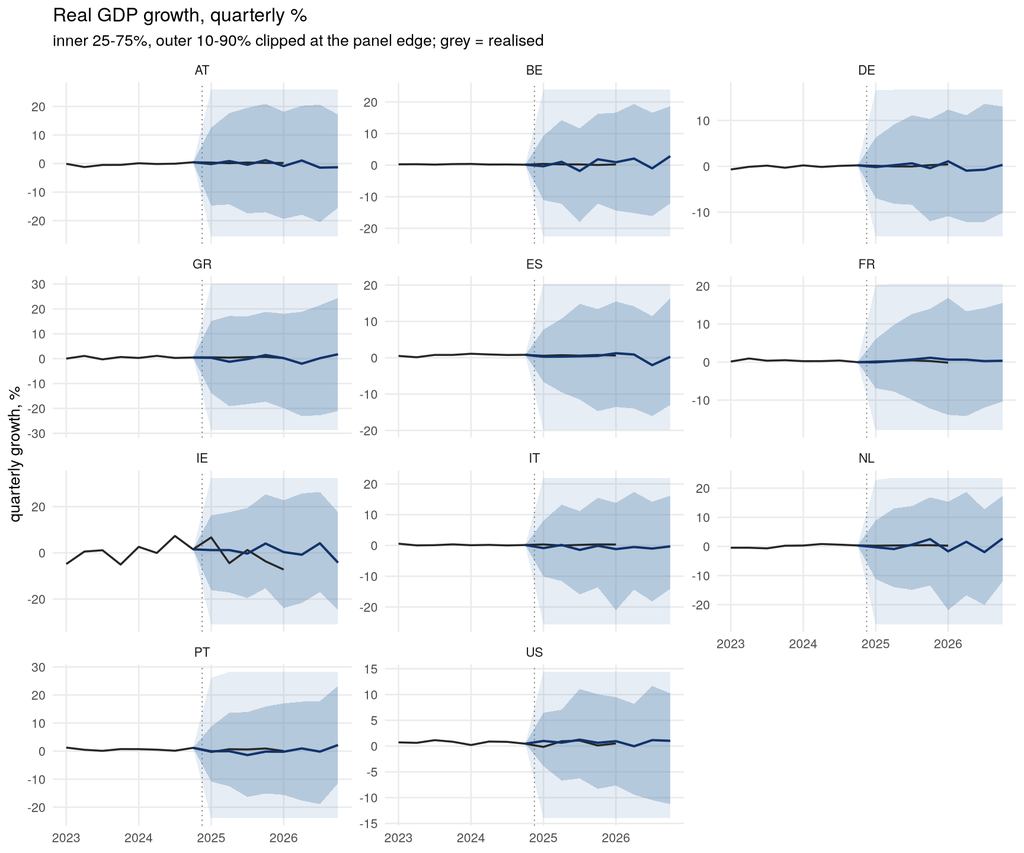

Median GDP growth forecast by quarter, percent.

| quarter | AT | BE | DE | GR | ES | FR | IE | IT | NL | PT | US |
| --- | --- | --- | --- | --- | --- | --- | --- | --- | --- | --- | --- |
| 2025Q1 | -0.16 | -0.35 | -0.15 | 0.35 | 0.29 | -0.05 | 1.21 | -0.86 | -0.27 | -0.06 | 1.00 |
| 2025Q2 | 0.88 | 1.05 | 0.25 | -1.25 | 0.32 | 0.28 | 1.20 | 0.16 | -0.91 | -0.02 | 0.66 |
| 2025Q3 | -0.42 | -1.84 | 0.65 | -0.18 | 0.41 | 0.67 | -0.29 | -1.45 | 0.60 | -1.41 | 1.24 |
| 2025Q4 | 1.19 | 1.85 | -0.41 | 1.45 | 0.52 | 1.13 | 4.05 | -0.11 | 2.51 | -0.18 | 0.64 |
| 2026Q1 | -0.89 | 0.92 | 1.10 | 0.20 | 1.25 | 0.65 | 0.35 | -1.19 | -1.68 | -0.21 | 0.95 |
| 2026Q2 | 1.06 | 2.07 | -0.94 | -2.02 | 0.89 | 0.63 | -0.79 | -0.51 | 1.60 | 0.96 | -0.03 |
| 2026Q3 | -1.43 | -1.02 | -0.73 | 0.19 | -2.03 | 0.25 | 4.16 | -1.01 | -1.94 | -0.18 | 1.16 |
| 2026Q4 | -1.31 | 2.85 | 0.32 | 1.77 | 0.27 | 0.34 | -4.24 | -0.30 | 2.71 | 2.18 | 1.02 |

### Prices

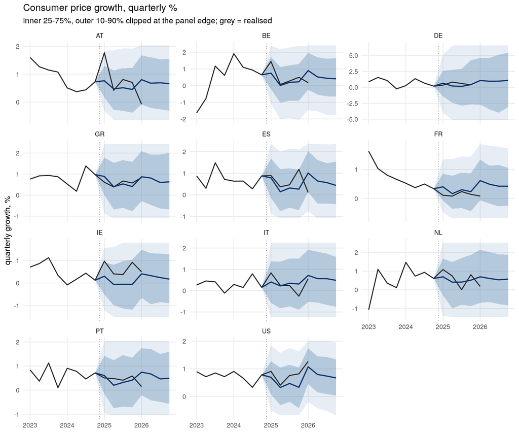

Median price growth forecast by quarter, percent.

| quarter | AT | BE | DE | GR | ES | FR | IE | IT | NL | PT | US |
| --- | --- | --- | --- | --- | --- | --- | --- | --- | --- | --- | --- |
| 2025Q1 | 0.76 | 0.75 | 0.65 | 0.89 | 0.79 | 0.40 | 0.30 | 0.41 | 0.69 | 0.60 | 0.69 |
| 2025Q2 | 0.47 | 0.01 | 0.21 | 0.40 | 0.14 | 0.17 | -0.06 | 0.22 | 0.41 | 0.20 | 0.33 |
| 2025Q3 | 0.51 | 0.19 | 0.15 | 0.53 | 0.32 | 0.30 | -0.06 | 0.35 | 0.41 | 0.32 | 0.47 |
| 2025Q4 | 0.45 | 0.23 | 0.43 | 0.41 | 0.26 | 0.24 | -0.06 | 0.31 | 0.51 | 0.41 | 0.33 |
| 2026Q1 | 0.80 | 0.90 | 1.07 | 0.87 | 1.01 | 0.61 | 0.41 | 0.71 | 0.69 | 0.75 | 1.07 |
| 2026Q2 | 0.67 | 0.52 | 0.96 | 0.81 | 0.64 | 0.49 | 0.33 | 0.56 | 0.61 | 0.67 | 0.80 |
| 2026Q3 | 0.69 | 0.44 | 0.97 | 0.60 | 0.57 | 0.42 | 0.24 | 0.56 | 0.53 | 0.47 | 0.74 |
| 2026Q4 | 0.66 | 0.41 | 1.10 | 0.63 | 0.44 | 0.42 | 0.17 | 0.48 | 0.57 | 0.49 | 0.67 |

### The block variables

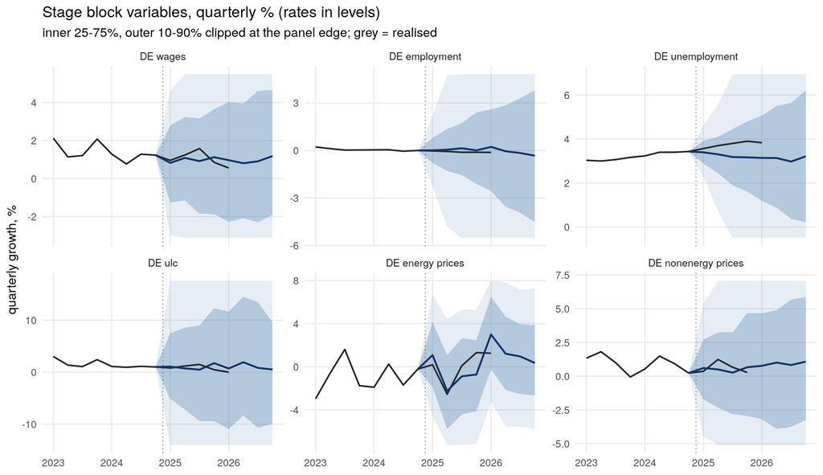

### What was discarded, and what the exogenous path assumes

Share of posterior draws discarded as explosive, by variable.

| variable | explosive share, h1 | h8 | max |
| --- | --- | --- | --- |
| at_gdp | 0.119 | 0.749 | 0.749 |
| it_gdp | 0.110 | 0.725 | 0.725 |
| nl_gdp | 0.089 | 0.724 | 0.724 |
| gr_gdp | 0.156 | 0.721 | 0.721 |
| pt_gdp | 0.092 | 0.718 | 0.718 |
| be_gdp | 0.090 | 0.714 | 0.714 |
| es_gdp | 0.078 | 0.702 | 0.702 |
| fr_gdp | 0.056 | 0.695 | 0.695 |
| ie_gdp | 0.062 | 0.686 | 0.686 |
| de_gdp | 0.049 | 0.662 | 0.662 |
| us_gdp | 0.054 | 0.631 | 0.631 |
| de_prices | 0.009 | 0.524 | 0.524 |
| at_prices | 0.000 | 0.000 | 0.000 |
| be_prices | 0.000 | 0.000 | 0.000 |
| gr_prices | 0.000 | 0.000 | 0.000 |
| es_prices | 0.000 | 0.000 | 0.000 |
| fr_prices | 0.000 | 0.000 | 0.000 |
| ie_prices | 0.000 | 0.000 | 0.000 |
| it_prices | 0.000 | 0.000 | 0.000 |
| nl_prices | 0.000 | 0.000 | 0.000 |
| pt_prices | 0.000 | 0.000 | 0.000 |
| us_prices | 0.000 | 0.000 | 0.000 |

The untruncated predictive band at horizon 8 – quarterly growth, percent. This is what the charts clip.

| variable | median | inner_low | inner_high | outer_low | outer_high | outer_width |
| --- | --- | --- | --- | --- | --- | --- |
| at_gdp | -1.3 | -15.5 | 17.2 | -45.5 | 47.0 | 92.5 |
| be_gdp | 2.9 | -12.1 | 18.7 | -39.9 | 49.1 | 89.0 |
| de_gdp | 0.3 | -10.1 | 13.1 | -34.8 | 38.9 | 73.7 |
| gr_gdp | 1.8 | -21.1 | 24.4 | -53.2 | 55.3 | 108.5 |
| es_gdp | 0.3 | -13.0 | 16.5 | -50.0 | 43.3 | 93.3 |
| fr_gdp | 0.3 | -10.4 | 15.5 | -40.1 | 52.8 | 92.9 |
| ie_gdp | -4.2 | -24.8 | 17.6 | -47.5 | 45.5 | 93.0 |
| it_gdp | -0.3 | -14.1 | 16.1 | -41.3 | 42.4 | 83.7 |
| nl_gdp | 2.7 | -12.1 | 17.4 | -42.3 | 49.5 | 91.8 |
| pt_gdp | 2.2 | -11.5 | 23.2 | -33.3 | 48.7 | 82.0 |
| us_gdp | 1.0 | -11.3 | 10.2 | -39.3 | 35.6 | 74.9 |
| at_prices | 0.7 | -0.3 | 1.5 | -1.3 | 2.5 | 3.8 |
| be_prices | 0.4 | -0.7 | 1.6 | -1.7 | 2.7 | 4.4 |
| de_prices | 1.1 | -3.1 | 5.4 | -18.7 | 20.6 | 39.3 |
| gr_prices | 0.6 | -0.7 | 2.0 | -1.8 | 3.5 | 5.3 |
| es_prices | 0.4 | -0.4 | 1.5 | -1.3 | 2.4 | 3.7 |
| fr_prices | 0.4 | -0.2 | 1.1 | -0.9 | 1.7 | 2.6 |
| ie_prices | 0.2 | -0.9 | 1.3 | -2.2 | 2.4 | 4.6 |
| it_prices | 0.5 | -0.8 | 1.6 | -2.0 | 2.7 | 4.7 |
| nl_prices | 0.6 | -0.8 | 1.9 | -2.2 | 3.2 | 5.4 |
| pt_prices | 0.5 | -0.6 | 1.6 | -1.6 | 2.7 | 4.3 |
| us_prices | 0.7 | 0.0 | 1.3 | -0.7 | 2.0 | 2.7 |

A forecast this long needs the **exogenous** series to reach the end of the horizon, and they do not: every one of them stops at the fit’s own native forecast end. `extend_forecast_horizon()` carries each one forward on its trailing four-quarter average growth – a momentum continuation, not a view on oil markets or world trade – and koma would otherwise have silently returned a shorter horizon than the one requested.

How each exogenous series was carried past the fit’s native forecast end.

| variable | method | periods_added |
| --- | --- | --- |
| covid_2020q1 | zero (dummy) | 3 |
| covid_2020q2 | zero (dummy) | 3 |
| covid_2020q3 | zero (dummy) | 3 |
| covid_2021q2 | zero (dummy) | 3 |
| eur_usd | trailing-4Q avg growth (2.67%/q) | 3 |
| oil_price | trailing-4Q avg growth (1.41%/q) | 3 |
| de_foreign_prices | trailing-4Q avg growth (0.11%/q) | 3 |
| row_gdp | trailing-4Q avg growth (0.72%/q) | 3 |